# Randomness

## Preamble

```r
load.pac <- function() {

  if(require("pacman")){
    library(pacman)
  }else{
    install.packages("pacman")
    library(pacman)
  }

  pacman::p_load(xts, sp, gstat, ggplot2, rmarkdown, reshape2, ggmap,
                 parallel, dplyr, plotly, tidyverse, reticulate, UsingR, Rmpfr)

}

load.pac()
```

## (1) Compute tables of $\pi$ digits

First it is necessary to have some digits of pi, we’ll just take a dataset:

```r
pi_Dig <- UsingR::pi2000[-1]
write.csv(pi_Dig, file = "./piDigits.csv", quote = FALSE, row.names = FALSE)
pi_Tibble <- tibble::enframe(piDig)
tibble::remove_rownames(pi_Tibble)
```

```
## # A tibble: 1,999 x 2
##     name value
##    <int> <dbl>
##  1     1     1
##  2     2     4
##  3     3     1
##  4     4     5
##  5     5     9
##  6     6     2
##  7     7     6
##  8     8     5
##  9     9     3
## 10    10     5
## # … with 1,989 more rows
```

```r
pi_Tibble <- pi_Tibble$value
head(pi_Tibble)
```

```
## [1] 1 4 1 5 9 2
```

### using the `Rmpfr` package

An alternative is to use the Rmpfr package deals with handling numbers of arbitrary precision, this requires the `GMP C` library to be installed, so the package will be something like `libbmp-dev` and should be in the repos for `apt` or `pacman -S` or whatever:

```bash
apt list libgmp3-dev
apt list libgmp
apt list libmpfr-dev


apt list libgmp3-dev libgmp libmpfr-dev
```

```
##
## WARNING: apt does not have a stable CLI interface. Use with caution in scripts.
##
## Listing...
## libgmp3-dev/bionic,now 2:6.1.2+dfsg-2 amd64 [installed]
##
## WARNING: apt does not have a stable CLI interface. Use with caution in scripts.
##
## Listing...
##
## WARNING: apt does not have a stable CLI interface. Use with caution in scripts.
##
## Listing...
## libmpfr-dev/bionic,now 4.0.1-1 amd64 [installed]
##
## WARNING: apt does not have a stable CLI interface. Use with caution in scripts.
##
## Listing...
## libgmp3-dev/bionic,now 2:6.1.2+dfsg-2 amd64 [installed]
## libmpfr-dev/bionic,now 4.0.1-1 amd64 [installed]
```

Rather than specifying significant figures the package works with bits of precision, so for example a base 10 number like 8 can be represented with 3 bits of information because $2^3=8$.

if 1000 decimal places were required, the number of bits would be the number of binary values necessary to represent that same value:

$$\begin{aligned}
2^{\textsf{bits}} &= 10^{\textsf{digits}} \\
\iff \textsf{bits} &= \textsf{digits} \times \log_{2}{}{\left( 10\right) }\\
\end{aligned}$$

```r
library(Rmpfr)
diglength <- 2000

precision <- diglength*log2(10)
precision <- ceiling(precision)
piVal <- Rmpfr::Const("pi", precision)
print(Rmpfr::Const("pi", 12*log2(10)))
```

```
## 1 'mpfr' number of precision  39   bits
## [1] 3.141592653592
```

In order to extract the value use `substring()` in order to create substrings of the values.

```r
piVal      <- format(piVal)
pi_Digits  <- substring(text = piVal, first = 1:diglength, last = 1:diglength)[3:diglength] #%>% as.numeric()
pi_Digits  <- substring(text = piVal, first = 1:diglength, last = 1:diglength)[3:diglength] %>% as.integer()
pi_Digits <- as.vector(pi_Digits)
#pi_Digits <- factor(pi_Digits, levels = 0:9, ordered = TRUE)
```

A histogram of which may be generated:

```r
table(pi_Digits)
```

```
## pi_Digits
##   0   1   2   3   4   5   6   7   8   9
## 181 212 207 188 195 205 200 197 202 211
```

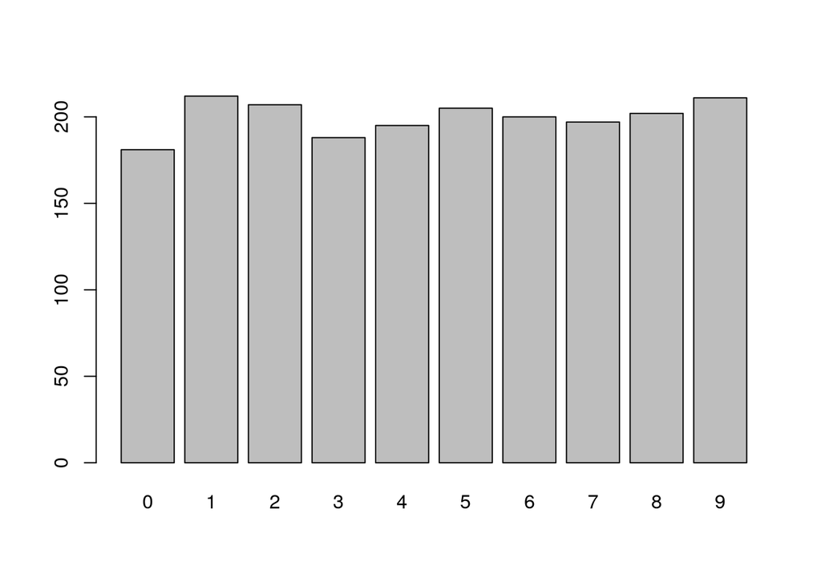

```r
table(pi_Digits) %>% barplot
```

The problem with a histogram is that it will combine The first two frequencies in a way that is incorrect in this context, it only seems to do it with the pi digits though for some reason

```r
hist(pi_Digits, breaks = seq(from = 0, to = 9, by = 1)) %>% summary()
```

```
##          Length Class  Mode
## breaks   10     -none- numeric
## counts    9     -none- numeric
## density   9     -none- numeric
## mids      9     -none- numeric
## xname     1     -none- character
## equidist  1     -none- logical
```

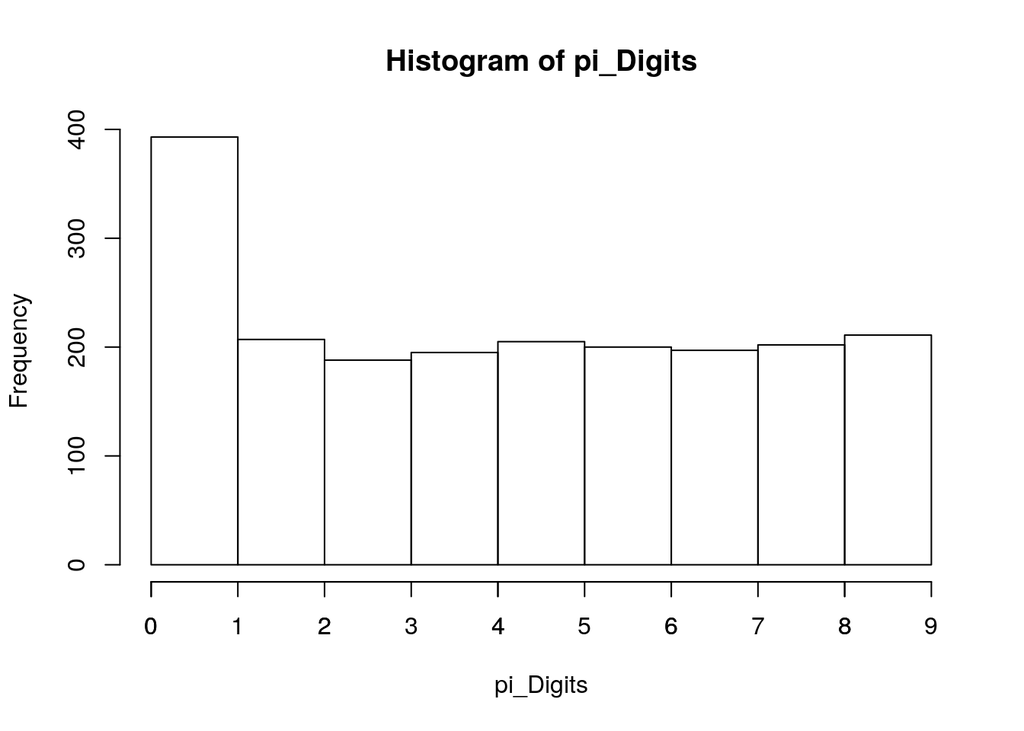

```r
axis(side = 1, at = seq(0, 9, 1), labels = seq(0, 9, 1))
axis(2,pos = -9)
```

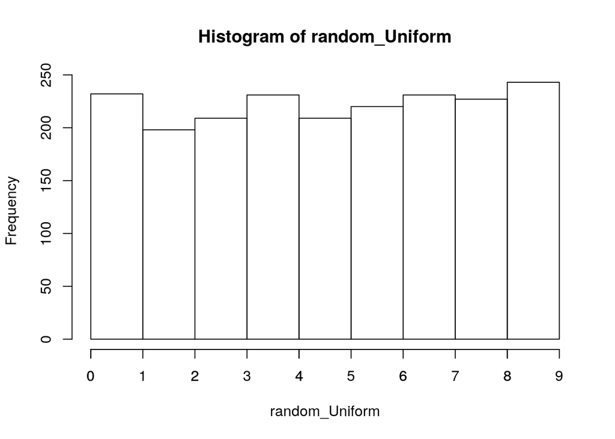

```r
random_Uniform <- runif(2000, 0, 9)
hist(random_Uniform)
axis(side = 1, at = seq(0, 9, 1), labels = seq(0, 9, 1))
axis(2,pos = -9)
```

A better alternative is to use ggplot2

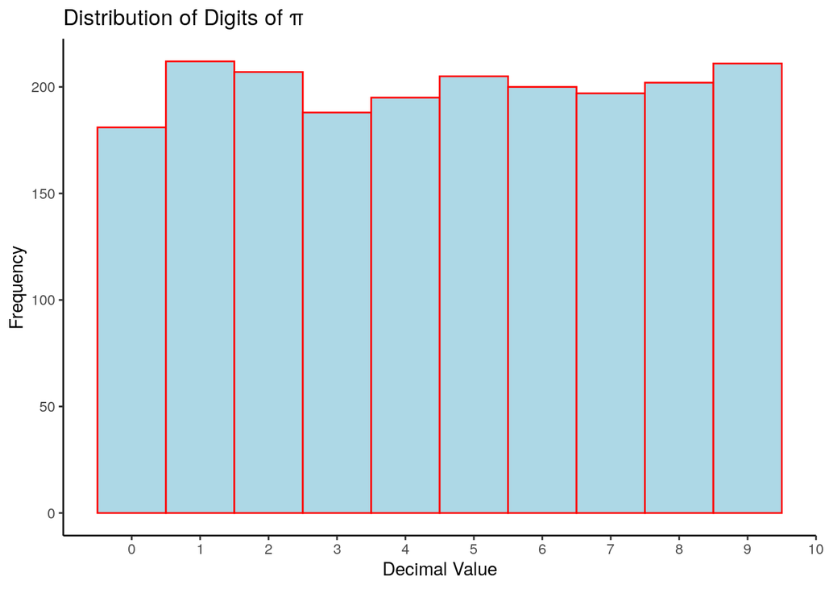

```r
pi_DigitsDF <- tibble::enframe(pi_Digits)

HistPlot <- function (DataFrame, heading) {
ggplot(data = DataFrame, aes(x = value, fill = value)) +
#       geom_histogram(binwidth = 1, fill = "lightblue", col = "red") +
       geom_histogram(bins = 10, fill = "lightblue", col = "red") +
       theme_classic() +
       scale_x_continuous(breaks = seq(0, 10, 1)) +
       labs(x = "Decimal Value", y = "Frequency",
        title = heading)

}

HistPlot(pi_DigitsDF, "Distribution of Digits of π" )
```

### Using Power Series

Using integration by parts, it can be shown that:

$$\begin{aligned}
\int^{b}_{0} \frac{1}{1+ x^2} \mathrm{d}x&= \arctan\left( b \right) \enspace : \quad b \in\left( \mathbb{R}^+\cap 0 \right) \\
\implies \int^{1}_{0} \frac{1}{1+ x^2} \mathrm{d}x&= \arctan\left( 1 \right) \\
\implies \int^{1}_{0} \frac{1}{1+ x^2} \mathrm{d}x&= \arctan\left( 1 \right) \\
\end{aligned}$$
Transforming into a a power series with some other magic:

$$\begin{aligned}
\implies \pi &= 4 \times \sum^\infty_{n=0}\left[ \frac{\left( - 1 \right) ^k}{2k+ 1} \right]
\end{aligned}$$

The problem with this is that the convergence is too slow to be useful:

$$\begin{aligned}
\frac{1}{2k+ 1} \leq 10^{100} \implies k\geq 10^{100} \times \frac{1}{2} - 1
\end{aligned}$$

presuming 1 sum per cycle at 5 GHz this would take well in excess of the age of the universe. There are ways to speed it up but it’s all well outside scope

## (4) Evaluate Distribution of pi Digits

In order to evaluate whether or not the digits of pi appear uniformally distriuted first consider the first 50 digits:

### First 50 Digits of pi

```r
count <- table(pi_Digits[1:50])
rss   <- (table(pi_Digits[1:50])-50/10)^2

piDigErrorDF        <- data.frame(0:9, as.vector(count), as.vector(rss))
names(piDigErrorDF) <- c("value", "Count", "SquareError")

print(piDigErrorDF)
```

```
##    value Count SquareError
## 1      0     2           9
## 2      1     5           0
## 3      2     5           0
## 4      3     8           9
## 5      4     4           1
## 6      5     5           0
## 7      6     4           1
## 8      7     4           1
## 9      8     5           0
## 10     9     8           9
```

```r
SSE <- sum(piDigErrorDF$SquareError)

print(paste("The Sum of Squared Errors is", SSE))
```

```
## [1] "The Sum of Squared Errors is 30"
```

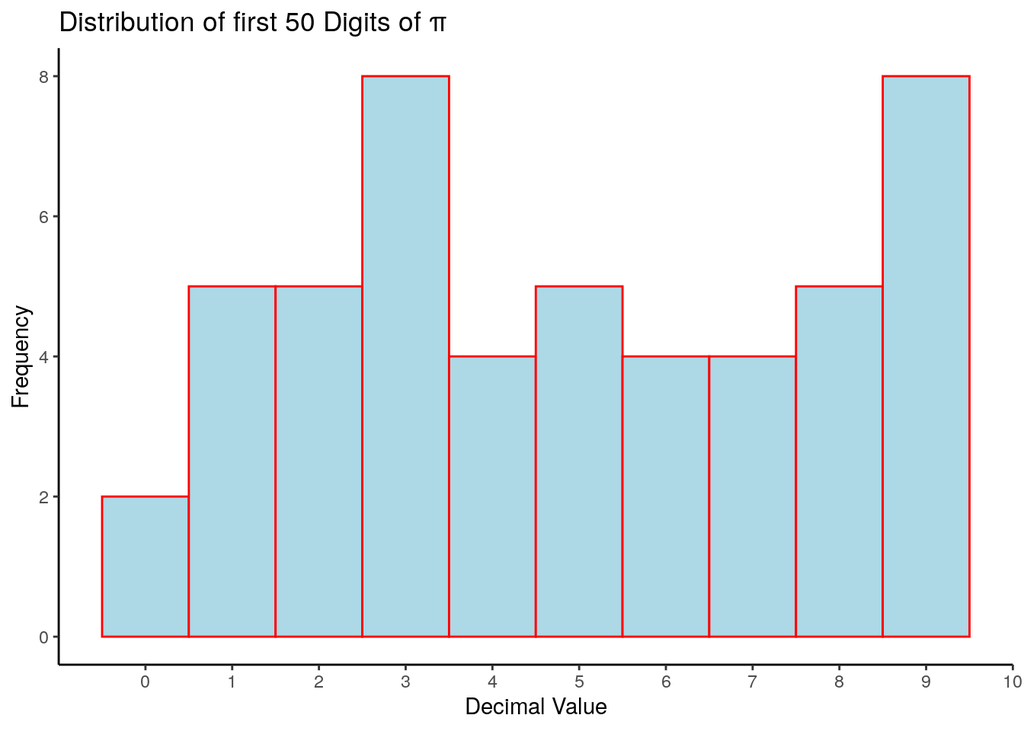

```r
HistPlot(pi_DigitsDF[1:50,], "Distribution of first 50 Digits of π")
```

### First 200 Digits of Pi

```r
count <- table(pi_Digits[1:200])
rss   <- (table(pi_Digits[1:200])-200/10)^2

piDigErrorDF        <- data.frame(0:9, as.vector(count), as.vector(rss))
names(piDigErrorDF) <- c("value", "Count", "SquareError")

print(piDigErrorDF)
```

```
##    value Count SquareError
## 1      0    19           1
## 2      1    20           0
## 3      2    24          16
## 4      3    19           1
## 5      4    22           4
## 6      5    20           0
## 7      6    16          16
## 8      7    12          64
## 9      8    25          25
## 10     9    23           9
```

```r
SSE <- sum(piDigErrorDF$SquareError)

print(paste("The Sum of Squared Errors is", SSE))
```

```
## [1] "The Sum of Squared Errors is 136"
```

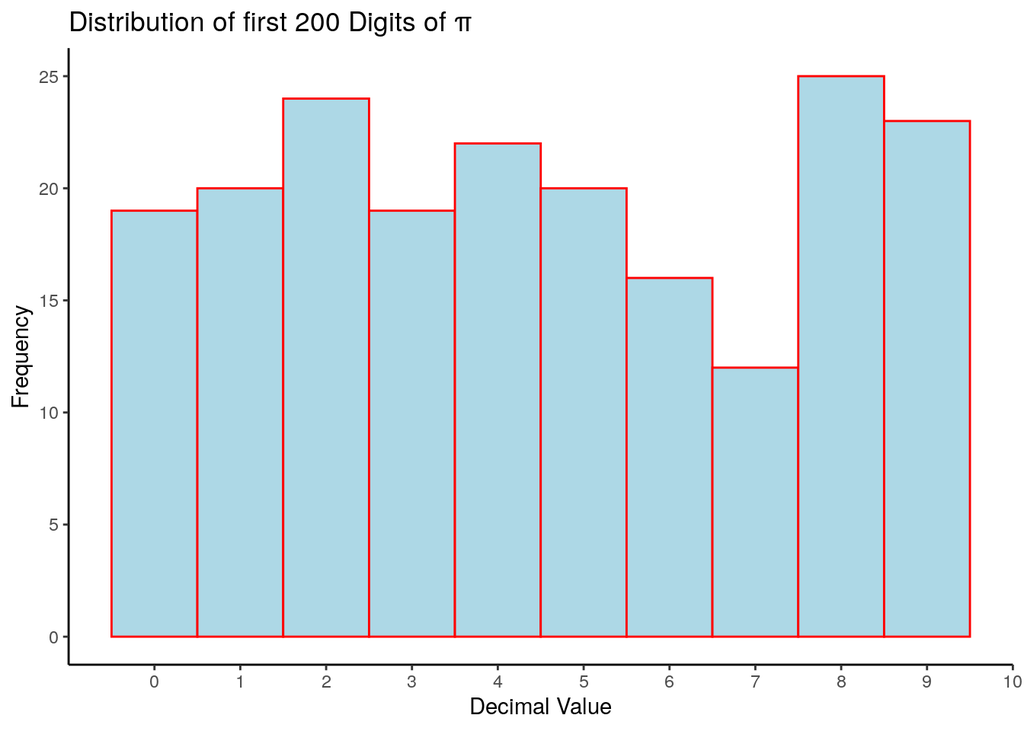

```r
HistPlot(pi_DigitsDF[1:200,], "Distribution of first 200 Digits of π")
```

### First 500 Digits of Pi

```r
count <- table(pi_Digits[1:500])
rss   <- (table(pi_Digits[1:500])-500/10)^2

piDigErrorDF        <- data.frame(0:9, as.vector(count), as.vector(rss))
names(piDigErrorDF) <- c("value", "Count", "SquareError")

print(piDigErrorDF)
```

```
##    value Count SquareError
## 1      0    45          25
## 2      1    59          81
## 3      2    54          16
## 4      3    50           0
## 5      4    53           9
## 6      5    50           0
## 7      6    48           4
## 8      7    36         196
## 9      8    53           9
## 10     9    52           4
```

```r
SSE <- sum(piDigErrorDF$SquareError)

print(paste("The Sum of Squared Errors is", SSE))
```

```
## [1] "The Sum of Squared Errors is 344"
```

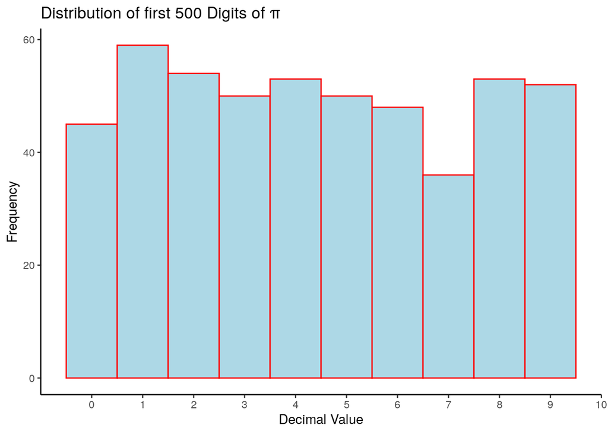

```r
HistPlot(pi_DigitsDF[1:500,], "Distribution of first 500 Digits of π")
```

### Random Sample of pi Digits

In *R* sampling something with repetition is referred to replacing, so to count or sample something with repetition specify `replace = TRUE`. Recall the counting Formulas:

| selection | ordered | unordered |
| --- | --- | --- |
| With Repetition | $n^m$ | $\binom{m+n-1}{n}$ |
| Without Repetition | $n_{(m)}$ | $\binom{n}{m}$ |

Where:

- $\binom{n}{m} =\frac{m_(k)}{k!}=\frac{m!}{k!(m-k)!}$
- $n_{(m)}=\frac{n!}{(n-m)!}$
- $n! = n \times (n-1) \times (n-2) \times 2 \times 1$

In order to randomly sample the digits of Pi:

```r
index <- sample(1:diglength, size = 200)
print(table(pi_Digits[index]))
```

```
##
##  0  1  2  3  4  5  6  7  8  9
## 16 18 25 16 19 27 21 25 11 22
```

[figure not shown]

```r
HistPlot(pi_DigitsDF[index,], "Distribution of first 50 Digits of π")
```

This can be repeated multiple times:

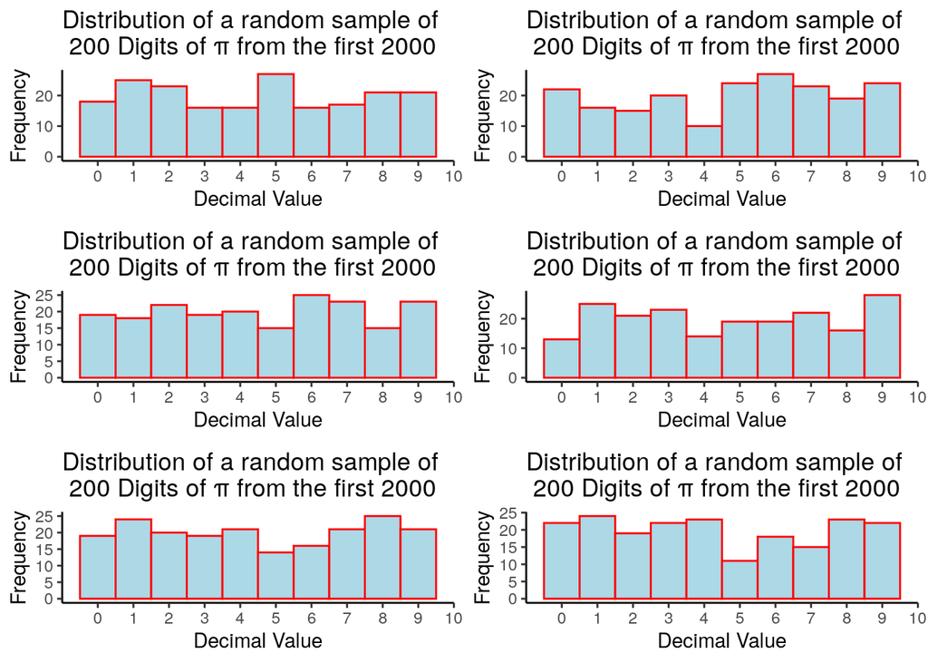

```r
library(gridExtra)
library(tidyverse)

PlotList <- list()
for (i in 1:6) {
index <- sample(1:diglength, size = 200)
PlotList[[i]] <- HistPlot(pi_DigitsDF[index,],
              paste("Distribution of a random sample of \n 200 Digits of π from the first", diglength))
}

# arrangeGrob(grobs = PlotList, layout_matrix = matrix(1:6, nrow = 3))
grid.arrange(grobs = PlotList, layout_matrix = matrix(1:6, nrow = 3))
```

## (5) Uniformally Distributed Values

### 50 Digits

```r
x <- runif(50, 0, 9) %>% round()
x <- sample(0:9, replace = TRUE, size = 50)
xDF <- tibble::enframe(x)

count <- table(x[1:50])
rss   <- (table(x[1:50])-50/10)^2

ErrorDF        <- data.frame(0:9, as.vector(count), as.vector(rss))
names(DF) <- c("value", "Count", "SquareError")

print(piDigErrorDF)
```

```
##    value Count SquareError
## 1      0    45          25
## 2      1    59          81
## 3      2    54          16
## 4      3    50           0
## 5      4    53           9
## 6      5    50           0
## 7      6    48           4
## 8      7    36         196
## 9      8    53           9
## 10     9    52           4
```

```r
SSE <- sum(piDigErrorDF$SquareError)

print(paste("The Sum of Squared Errors is", SSE))
```

```
## [1] "The Sum of Squared Errors is 344"
```

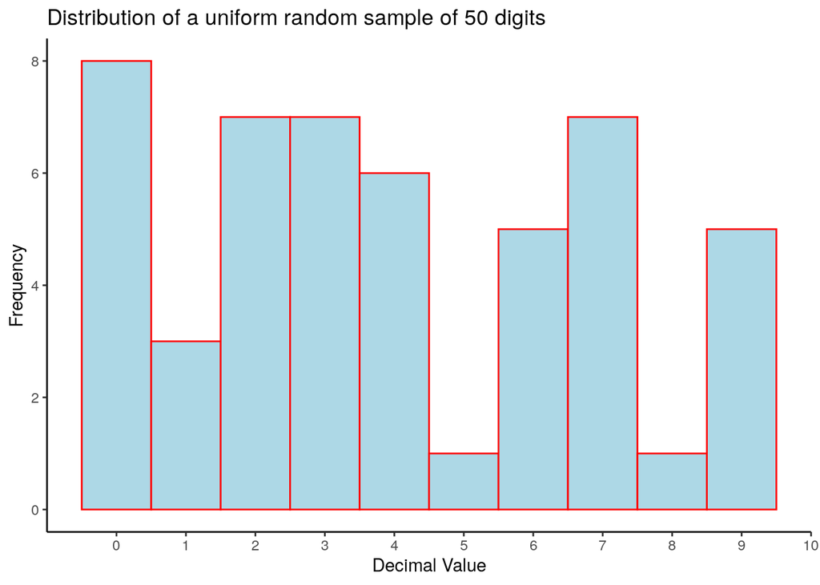

```r
HistPlot(xDF[1:50,], "Distribution of a uniform random sample of 50 digits")
```

### 200 Digits

```r
x <- runif(200, 0, 9) %>% round()
x <- sample(0:9, replace = TRUE, size = 200)
xDF <- tibble::enframe(x)

count <- table(x[1:200])
rss   <- (table(x[1:200])-200/10)^2

ErrorDF        <- data.frame(0:9, as.vector(count), as.vector(rss))
names(DF) <- c("value", "Count", "SquareError")

print(piDigErrorDF)
```

```
##    value Count SquareError
## 1      0    45          25
## 2      1    59          81
## 3      2    54          16
## 4      3    50           0
## 5      4    53           9
## 6      5    50           0
## 7      6    48           4
## 8      7    36         196
## 9      8    53           9
## 10     9    52           4
```

```r
SSE <- sum(piDigErrorDF$SquareError)

print(paste("The Sum of Squared Errors is", SSE))
```

```
## [1] "The Sum of Squared Errors is 344"
```

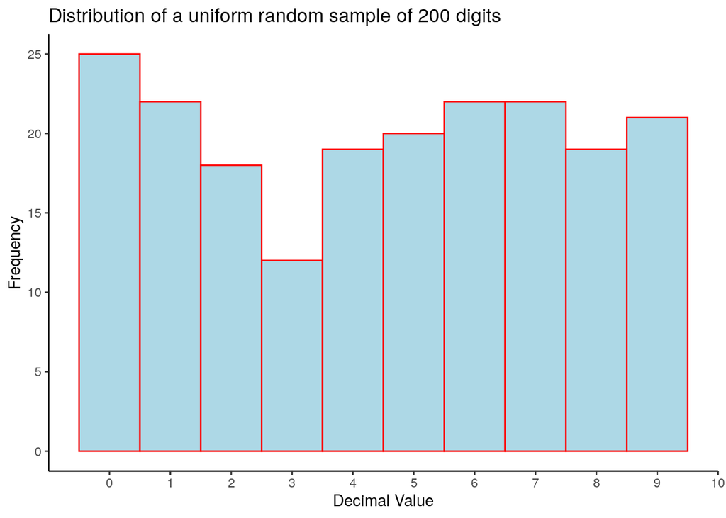

```r
HistPlot(xDF[1:200,], "Distribution of a uniform random sample of 200 digits")
```

### 500 Digits

```r
x <- runif(500, 0, 9) %>% round()
x <- sample(0:9, replace = TRUE, size = 500)
xDF <- tibble::enframe(x)

count <- table(x[1:500])
rss   <- (table(x[1:500])-500/10)^2

ErrorDF        <- data.frame(0:9, as.vector(count), as.vector(rss))
names(DF) <- c("value", "Count", "SquareError")

print(piDigErrorDF)
```

```
##    value Count SquareError
## 1      0    45          25
## 2      1    59          81
## 3      2    54          16
## 4      3    50           0
## 5      4    53           9
## 6      5    50           0
## 7      6    48           4
## 8      7    36         196
## 9      8    53           9
## 10     9    52           4
```

```r
SSE <- sum(piDigErrorDF$SquareError)

print(paste("The Sum of Squared Errors is", SSE))
```

```
## [1] "The Sum of Squared Errors is 344"
```

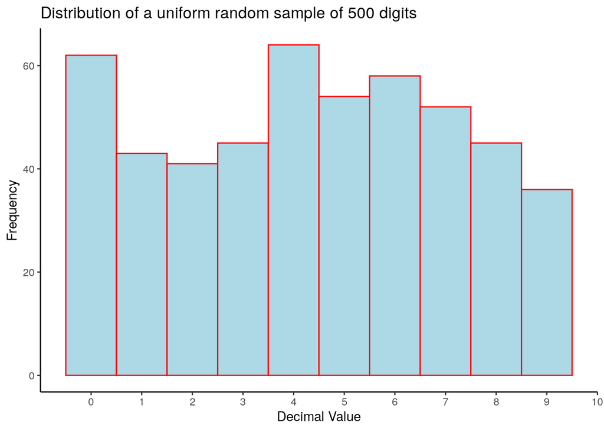

```r
HistPlot(xDF[1:500,], "Distribution of a uniform random sample of 500 digits")
```

## (6) Repeat for multiple larger digits

I did 50, 200 and 500 for all of them.